# Lesson 6 R Activity

Rick Davila

5/4/2020

## Lesson 6 - Install packages

#### Install necessary packages using library()

#### Perform data housekeeping - upload, name columns, display to make sure it reads properly, etc.

```r
knitr::opts_chunk$set(echo = TRUE)

library(e1071)
library(xtable)
library("xlsx") # Needed to read data
```

```r
library(car) # Needed for alternative scatterplot matrix to default
library(scatterplot3d) # Needed for 3D scatterplot
library(matlib) # Needed for Invers() function
library(MASS) # Needed for ginv() function
library(standardize) # Needed for unit normal scaling in Example 3.14
rm(list = ls())
```

#### Read data file (data-ex-3-1.xlsx)

```r
ex3_1 <- read.xlsx("data-ex-3-1.xlsx",
                   sheetIndex = 1,
                   colIndex = c(2,3,4),
                   as.data.frame = TRUE,
                   header = TRUE)
```

#### Assign labels to data columns using names() and attach() commands

```r
names(ex3_1) <- c("Delivery_Time", "Num_Cases", "Distance")
attach(ex3_1)
```

#### Output data to make sure it reads properly

```r
out <- as.data.frame(c(ex3_1))
colnames(out) <- c("Delivery Time, $y$ (min)", "Number of Cases, $x_i$","Distance, $x_2$ (ft)")
tab <- (xtable(out, digits=c(0,2,0,0)))
print(tab, type="html")
```

|  | Delivery Time, $y$ (min) | Number of Cases, $x_i$ | Distance, $x_2$ (ft) |
| --- | --- | --- | --- |
| 1 | 16.68 | 7 | 560 |
| 2 | 11.50 | 3 | 220 |
| 3 | 12.03 | 3 | 340 |
| 4 | 14.88 | 4 | 80 |
| 5 | 13.75 | 6 | 150 |
| 6 | 18.11 | 7 | 330 |
| 7 | 8.00 | 2 | 110 |
| 8 | 17.83 | 7 | 210 |
| 9 | 79.24 | 30 | 1460 |
| 10 | 21.50 | 5 | 605 |
| 11 | 40.33 | 16 | 688 |
| 12 | 21.00 | 10 | 215 |
| 13 | 13.50 | 4 | 255 |
| 14 | 19.75 | 6 | 462 |
| 15 | 24.00 | 9 | 448 |
| 16 | 29.00 | 10 | 776 |
| 17 | 15.35 | 6 | 200 |
| 18 | 19.00 | 7 | 132 |
| 19 | 9.50 | 3 | 36 |
| 20 | 35.10 | 17 | 770 |
| 21 | 17.90 | 10 | 140 |
| 22 | 52.32 | 26 | 810 |
| 23 | 18.75 | 9 | 450 |
| 24 | 19.83 | 8 | 635 |
| 25 | 10.75 | 4 | 150 |

```r
# Output data structure and dimensions
str(ex3_1)
```

‘data.frame’: 25 obs. of 3 variables: $ Delivery_Time: num 16.7 11.5 12 14.9 13.8 … $ Num_Cases : num 7 3 3 4 6 7 2 7 30 5 … $ Distance : num 560 220 340 80 150 330 110 210 1460 605 …

```r
dim(ex3_1)
```

[1] 25 3

## Lesson 6 - Example 4.1 (p.135-136)

#### Calculate residuals and compare to Column (1) in Table 4.1, p. 137.

```r
# Define X matrix of regressor observations
X <- cbind(matrix(1,length(Distance),1),as.matrix(Num_Cases),as.matrix(Distance))
y <- as.matrix(Delivery_Time)

# X'X matrix
xTx <- t(X) %*% X

# Calculate least-squares estimator of beta_coeffs
beta_hat <- ginv(xTx) %*% t(X) %*% y
beta_0 <- beta_hat[1,1]
beta_1 <- beta_hat[2,1]
beta_2 <- beta_hat[3,1]
```

The least squares fit is
$$\hat{y} = (2.3412311) + (1.6159072)x_1 + (0.0143848)x_2$$

```r
# least squares fit equation
y_hat <- beta_0 + beta_1*Num_Cases + beta_2*Distance
e_i=data.frame(Delivery_Time - y_hat) # e_i are the residuals
names(e_i) <- c("Res")
attach(e_i)

out <- as.data.frame(c(e_i))
colnames(out) <- c("Residuals")
tab <- (xtable(out, digits=c(0,6)))
print(tab, type="html")
```

|  | Residuals |
| --- | --- |
| 1 | -5.028084 |
| 2 | 1.146385 |
| 3 | -0.049794 |
| 4 | 4.924354 |
| 5 | -0.444398 |
| 6 | -0.289574 |
| 7 | 0.844624 |
| 8 | 1.156605 |
| 9 | 7.419706 |
| 10 | 2.376413 |
| 11 | 2.237493 |
| 12 | -0.593041 |
| 13 | 1.027009 |
| 14 | 1.067536 |
| 15 | 0.671202 |
| 16 | -0.662928 |
| 17 | 0.436360 |
| 18 | 3.448621 |
| 19 | 1.793193 |
| 20 | -5.787970 |
| 21 | -2.614179 |
| 22 | -3.686528 |
| 23 | -4.607568 |
| 24 | -4.572854 |
| 25 | -0.212584 |

#### Calculate standardized residuals using Equation 4.2;compare to Column (2) in Table 4.1, p. 137.

```r
n <- length(Res)       # number of residuals
ei_bar <- sum(Res)/n   # avg of residuals
k <- 2                 # number of beta regressor coefficients
p <- k + 1             # number of parameters

MS_Res <- sum((Res - ei_bar)^2)/(n-p)

# standardized residuals (eqn 4.2)
d_i <- data.frame(Res/(sqrt(MS_Res)))
names(d_i) <- c("Std_Res")
attach(d_i)

out <- as.data.frame(c(d_i))
colnames(out) <- c("Standardized Residuals")
tab <- (xtable(out, digits=c(0,6)))
print(tab, type="html")
```

|  | Standardized Residuals |
| --- | --- |
| 1 | -1.542606 |
| 2 | 0.351709 |
| 3 | -0.015277 |
| 4 | 1.510782 |
| 5 | -0.136341 |
| 6 | -0.088841 |
| 7 | 0.259129 |
| 8 | 0.354844 |
| 9 | 2.276351 |
| 10 | 0.729079 |
| 11 | 0.686458 |
| 12 | -0.181944 |
| 13 | 0.315084 |
| 14 | 0.327518 |
| 15 | 0.205923 |
| 16 | -0.203385 |
| 17 | 0.133874 |
| 18 | 1.058030 |
| 19 | 0.550148 |
| 20 | -1.775738 |
| 21 | -0.802025 |
| 22 | -1.131019 |
| 23 | -1.413593 |
| 24 | -1.402942 |
| 25 | -0.065220 |

#### Calculate studentized residuals using Equation 4.8; compare to Column (3) in Table 4.1, p. 137.

```r
# calculate the hat matrix
H <- X %*% ginv(xTx) %*% t(X)

# to get the diagonal elements of H, use diag(H) function

# studentized residuals (eqn 4.8)
r_i <- data.frame(Res/(sqrt(MS_Res*(1-diag(H)))))
names(r_i) <- c("Stud_Res")
attach(r_i)

out <- as.data.frame(c(r_i))
colnames(out) <- c("Studentized Residuals")
tab <- (xtable(out, digits=c(0,6)))
print(tab, type="html")
```

|  | Studentized Residuals |
| --- | --- |
| 1 | -1.627680 |
| 2 | 0.364843 |
| 3 | -0.016092 |
| 4 | 1.579720 |
| 5 | -0.141761 |
| 6 | -0.090808 |
| 7 | 0.270425 |
| 8 | 0.366721 |
| 9 | 3.213763 |
| 10 | 0.813254 |
| 11 | 0.718080 |
| 12 | -0.193257 |
| 13 | 0.325179 |
| 14 | 0.341135 |
| 15 | 0.210291 |
| 16 | -0.222700 |
| 17 | 0.138039 |
| 18 | 1.112952 |
| 19 | 0.578766 |
| 20 | -1.873546 |
| 21 | -0.877843 |
| 22 | -1.449995 |
| 23 | -1.443690 |
| 24 | -1.496059 |
| 25 | -0.067509 |

#### Calculate PRESS residuals using Equation 4.11; compare to Column (5) in Table 4.1, p. 137.

```r
# PRESS residuals (eqn 4.11)
e_pip <- data.frame(Res/(1-diag(H)))
names(e_pip) <- c("PRESS_Res")
attach(e_pip)

out <- as.data.frame(c(e_pip))
colnames(out) <- c("PRESS residuals")
tab <- (xtable(out, digits=c(0,6)))
print(tab, type="html")
```

|  | PRESS residuals |
| --- | --- |
| 1 | -5.597967 |
| 2 | 1.233603 |
| 3 | -0.055249 |
| 4 | 5.384013 |
| 5 | -0.480436 |
| 6 | -0.302543 |
| 7 | 0.919867 |
| 8 | 1.235327 |
| 9 | 14.788898 |
| 10 | 2.956826 |
| 11 | 2.448378 |
| 12 | -0.669086 |
| 13 | 1.093872 |
| 14 | 1.158154 |
| 15 | 0.699978 |
| 16 | -0.794821 |
| 17 | 0.463933 |
| 18 | 3.815946 |
| 19 | 1.984606 |
| 20 | -6.443140 |
| 21 | -3.131792 |
| 22 | -6.059135 |
| 23 | -4.805858 |
| 24 | -5.200019 |
| 25 | -0.227763 |

#### Calculate R-Student residuals using Equations 4.12 and 4.13; compare to Column (6) in Table 4.1, p. 137. Looks good.

```r
# using eqn 4.12
Si_sqr = ((n-p)*MS_Res-(Res^2/(1-diag(H))))/(n-p-1)

# R-student (eqn 4.13)
t_i <- data.frame(Res/(sqrt(Si_sqr*(1-diag(H)))))
names(t_i) <- c("R_Stud")
attach(t_i)

out <- as.data.frame(c(t_i))
colnames(out) <- c("R-Student Residuals")
tab <- (xtable(out, digits=c(0,6)))
print(tab, type="html")
```

|  | R-Student Residuals |
| --- | --- |
| 1 | -1.695629 |
| 2 | 0.357538 |
| 3 | -0.015722 |
| 4 | 1.639165 |
| 5 | -0.138565 |
| 6 | -0.088737 |
| 7 | 0.264648 |
| 8 | 0.359390 |
| 9 | 4.310780 |
| 10 | 0.806776 |
| 11 | 0.709939 |
| 12 | -0.188975 |
| 13 | 0.318469 |
| 14 | 0.334177 |
| 15 | 0.205663 |
| 16 | -0.217826 |
| 17 | 0.134924 |
| 18 | 1.119331 |
| 19 | 0.569814 |
| 20 | -1.996677 |
| 21 | -0.873087 |
| 22 | -1.489625 |
| 23 | -1.482467 |
| 24 | -1.542215 |
| 25 | -0.065963 |

#### Reproduce Table 4.1 on p. 137 - Consolidate above vectors into a dataframe using data.frame(). Give column names using colnames() and c().

```r
out <- as.data.frame(c(e_i, d_i, r_i, e_pip, t_i))
colnames(out) <- c(" Residuals, $e_i$ "," Standardized Residuals, $d_i$ "," Studentized Residuals, $r_i$ "," PRESS Residuals, $e_{(i)}$ "," R-student, $t_i$ ")
tab <- (xtable(out, digits=c(0, 6, 6, 6, 6, 6)))
print(tab, type="html")
```

|  | Residuals, $e_i$ | Standardized Residuals, $d_i$ | Studentized Residuals, $r_i$ | PRESS Residuals, $e_{(i)}$ | R-student, $t_i$ |
| --- | --- | --- | --- | --- | --- |
| 1 | -5.028084 | -1.542606 | -1.627680 | -5.597967 | -1.695629 |
| 2 | 1.146385 | 0.351709 | 0.364843 | 1.233603 | 0.357538 |
| 3 | -0.049794 | -0.015277 | -0.016092 | -0.055249 | -0.015722 |
| 4 | 4.924354 | 1.510782 | 1.579720 | 5.384013 | 1.639165 |
| 5 | -0.444398 | -0.136341 | -0.141761 | -0.480436 | -0.138565 |
| 6 | -0.289574 | -0.088841 | -0.090808 | -0.302543 | -0.088737 |
| 7 | 0.844624 | 0.259129 | 0.270425 | 0.919867 | 0.264648 |
| 8 | 1.156605 | 0.354844 | 0.366721 | 1.235327 | 0.359390 |
| 9 | 7.419706 | 2.276351 | 3.213763 | 14.788898 | 4.310780 |
| 10 | 2.376413 | 0.729079 | 0.813254 | 2.956826 | 0.806776 |
| 11 | 2.237493 | 0.686458 | 0.718080 | 2.448378 | 0.709939 |
| 12 | -0.593041 | -0.181944 | -0.193257 | -0.669086 | -0.188975 |
| 13 | 1.027009 | 0.315084 | 0.325179 | 1.093872 | 0.318469 |
| 14 | 1.067536 | 0.327518 | 0.341135 | 1.158154 | 0.334177 |
| 15 | 0.671202 | 0.205923 | 0.210291 | 0.699978 | 0.205663 |
| 16 | -0.662928 | -0.203385 | -0.222700 | -0.794821 | -0.217826 |
| 17 | 0.436360 | 0.133874 | 0.138039 | 0.463933 | 0.134924 |
| 18 | 3.448621 | 1.058030 | 1.112952 | 3.815946 | 1.119331 |
| 19 | 1.793193 | 0.550148 | 0.578766 | 1.984606 | 0.569814 |
| 20 | -5.787970 | -1.775738 | -1.873546 | -6.443140 | -1.996677 |
| 21 | -2.614179 | -0.802025 | -0.877843 | -3.131792 | -0.873087 |
| 22 | -3.686528 | -1.131019 | -1.449995 | -6.059135 | -1.489625 |
| 23 | -4.607568 | -1.413593 | -1.443690 | -4.805858 | -1.482467 |
| 24 | -4.572854 | -1.402942 | -1.496059 | -5.200019 | -1.542215 |
| 25 | -0.212584 | -0.065220 | -0.067509 | -0.227763 | -0.065963 |

#### Note: R has functions called rstandard() and rstudent(). Note that rstandard() outputs what the textbook calls Studentized Residuals and rstudent() outputs what the textbook calls R-Student residuals or ‘externally studentized’ residuals. Don’t get confused. Compare your manually-computer vectors above with the rstandard() and rstudent() functions. The rounded difference should be a vector of zeros.

```r
# test rstandard() function
test.lm <- lm(Delivery_Time~ Num_Cases + Distance)
test.rstandard <- data.frame(rstandard(test.lm))
test.rstudent <- data.frame(rstudent(test.lm))

out <- as.data.frame(c(e_i, d_i, r_i, e_pip, t_i, test.rstandard, test.rstudent))
colnames(out) <- c(" Residuals, $e_i$ "," Standardized Residuals, $d_i$ "," Studentized Residuals, $r_i$ "," PRESS Residuals, $e_{(i)}$ "," R-student, $t_i$ ", " rstandard() ", " rstudent() ")
tab <- (xtable(out, digits=c(0, 6, 6, 6, 6, 6, 6, 6)))
print(tab, type="html")
```

|  | Residuals, $e_i$ | Standardized Residuals, $d_i$ | Studentized Residuals, $r_i$ | PRESS Residuals, $e_{(i)}$ | R-student, $t_i$ | rstandard() | rstudent() |
| --- | --- | --- | --- | --- | --- | --- | --- |
| 1 | -5.028084 | -1.542606 | -1.627680 | -5.597967 | -1.695629 | -1.627680 | -1.695629 |
| 2 | 1.146385 | 0.351709 | 0.364843 | 1.233603 | 0.357538 | 0.364843 | 0.357538 |
| 3 | -0.049794 | -0.015277 | -0.016092 | -0.055249 | -0.015722 | -0.016092 | -0.015722 |
| 4 | 4.924354 | 1.510782 | 1.579720 | 5.384013 | 1.639165 | 1.579720 | 1.639165 |
| 5 | -0.444398 | -0.136341 | -0.141761 | -0.480436 | -0.138565 | -0.141761 | -0.138565 |
| 6 | -0.289574 | -0.088841 | -0.090808 | -0.302543 | -0.088737 | -0.090808 | -0.088737 |
| 7 | 0.844624 | 0.259129 | 0.270425 | 0.919867 | 0.264648 | 0.270425 | 0.264648 |
| 8 | 1.156605 | 0.354844 | 0.366721 | 1.235327 | 0.359390 | 0.366721 | 0.359390 |
| 9 | 7.419706 | 2.276351 | 3.213763 | 14.788898 | 4.310780 | 3.213763 | 4.310780 |
| 10 | 2.376413 | 0.729079 | 0.813254 | 2.956826 | 0.806776 | 0.813254 | 0.806776 |
| 11 | 2.237493 | 0.686458 | 0.718080 | 2.448378 | 0.709939 | 0.718080 | 0.709939 |
| 12 | -0.593041 | -0.181944 | -0.193257 | -0.669086 | -0.188975 | -0.193257 | -0.188975 |
| 13 | 1.027009 | 0.315084 | 0.325179 | 1.093872 | 0.318469 | 0.325179 | 0.318469 |
| 14 | 1.067536 | 0.327518 | 0.341135 | 1.158154 | 0.334177 | 0.341135 | 0.334177 |
| 15 | 0.671202 | 0.205923 | 0.210291 | 0.699978 | 0.205663 | 0.210291 | 0.205663 |
| 16 | -0.662928 | -0.203385 | -0.222700 | -0.794821 | -0.217826 | -0.222700 | -0.217826 |
| 17 | 0.436360 | 0.133874 | 0.138039 | 0.463933 | 0.134924 | 0.138039 | 0.134924 |
| 18 | 3.448621 | 1.058030 | 1.112952 | 3.815946 | 1.119331 | 1.112952 | 1.119331 |
| 19 | 1.793193 | 0.550148 | 0.578766 | 1.984606 | 0.569814 | 0.578766 | 0.569814 |
| 20 | -5.787970 | -1.775738 | -1.873546 | -6.443140 | -1.996677 | -1.873546 | -1.996677 |
| 21 | -2.614179 | -0.802025 | -0.877843 | -3.131792 | -0.873087 | -0.877843 | -0.873087 |
| 22 | -3.686528 | -1.131019 | -1.449995 | -6.059135 | -1.489625 | -1.449995 | -1.489625 |
| 23 | -4.607568 | -1.413593 | -1.443690 | -4.805858 | -1.482467 | -1.443690 | -1.482467 |
| 24 | -4.572854 | -1.402942 | -1.496059 | -5.200019 | -1.542215 | -1.496059 | -1.542215 |
| 25 | -0.212584 | -0.065220 | -0.067509 | -0.227763 | -0.065963 | -0.067509 | -0.065963 |

## Lesson 6 - Example 4.2 (p. 139-140)

#### Create plot of residuals against fitted y_hat values for each type of residual calculated in Example 4.1 using plot()

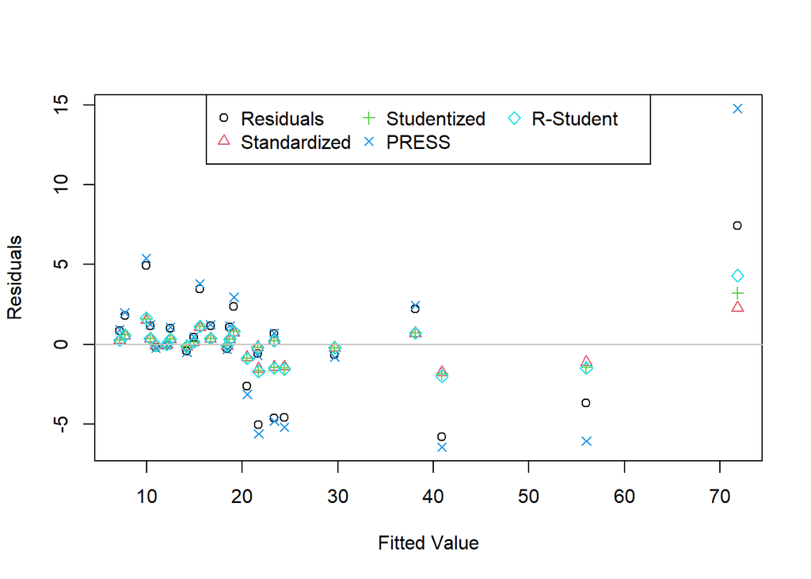

```r
# before plotting, get colors
cols <- palette()

# plot the first curve by calling plot() function
plot(y_hat, Res, ylab = "Residuals", xlab = "Fitted Value", col=cols[1], pch=1, ylim=range(Res, Std_Res, Stud_Res, PRESS_Res))
points(y_hat, Std_Res, col=cols[2], pch=2)
points(y_hat, Stud_Res, col=cols[3], pch=3)
points(y_hat, PRESS_Res, col=cols[4], pch=4)
points(y_hat, R_Stud, col=cols[5], pch=5)

abline(h=0, col="gray")

legend("top",legend=c("Residuals","Standardized","Studentized","PRESS","R-Student"), col=c(cols[1],cols[2],cols[3],cols[4],cols[5]), pch=c(1, 2, 3, 4, 5), ncol = 3)
```

#### Create normal probability plot of residuals using qqnorm()

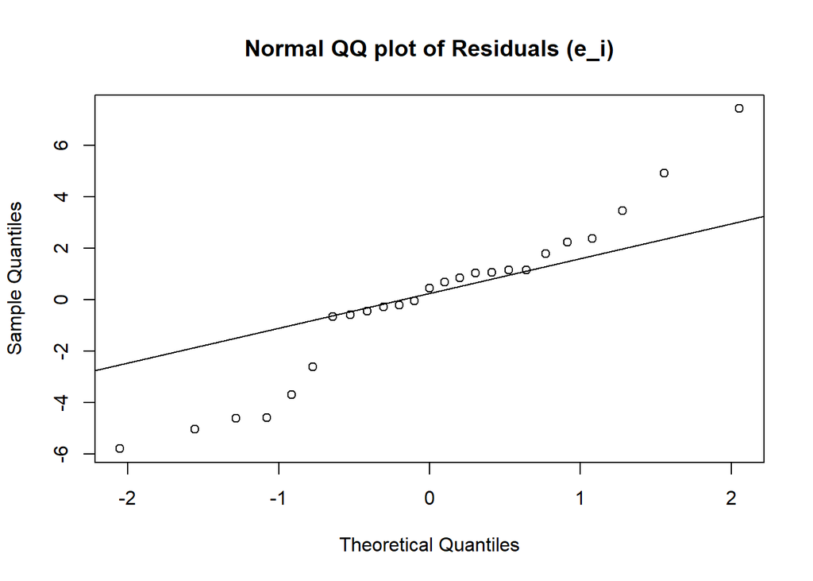

```r
# the normal probability plot is a graphical technique for assessing whether or not a data set is approximately normally distributed.  Departures from a straight line fit indicates depature from normality

qqnorm(Res,main="Normal QQ plot of Residuals (e_i)")
qqline(Res)
```

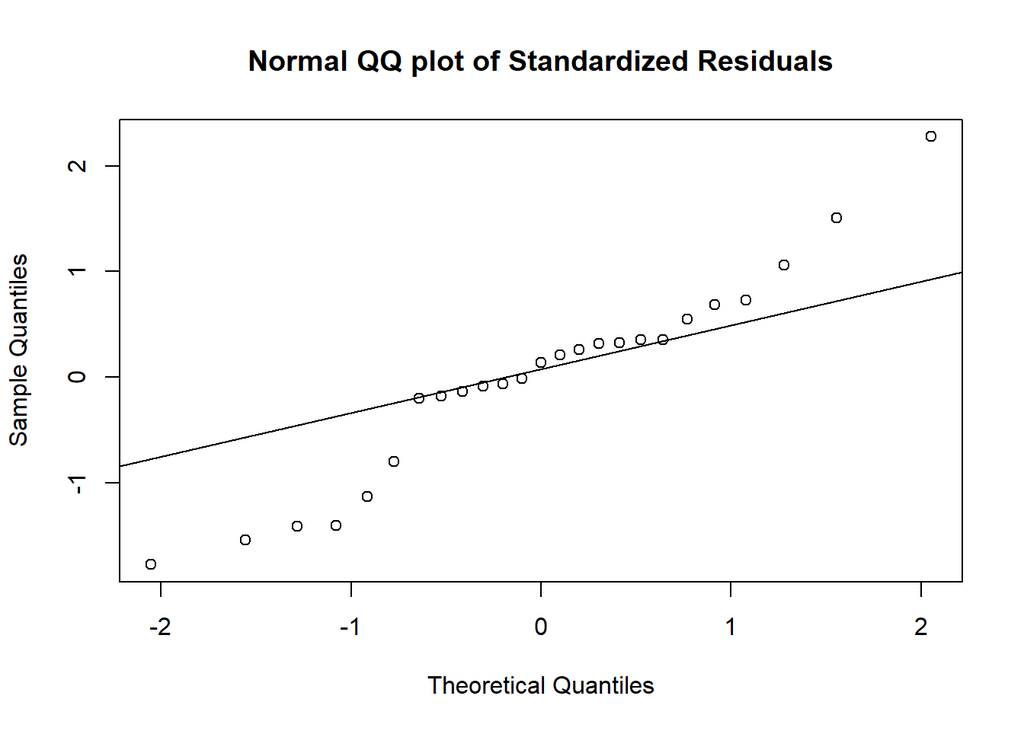

```r
qqnorm(Std_Res,main="Normal QQ plot of Standardized Residuals")
qqline(Std_Res)
```

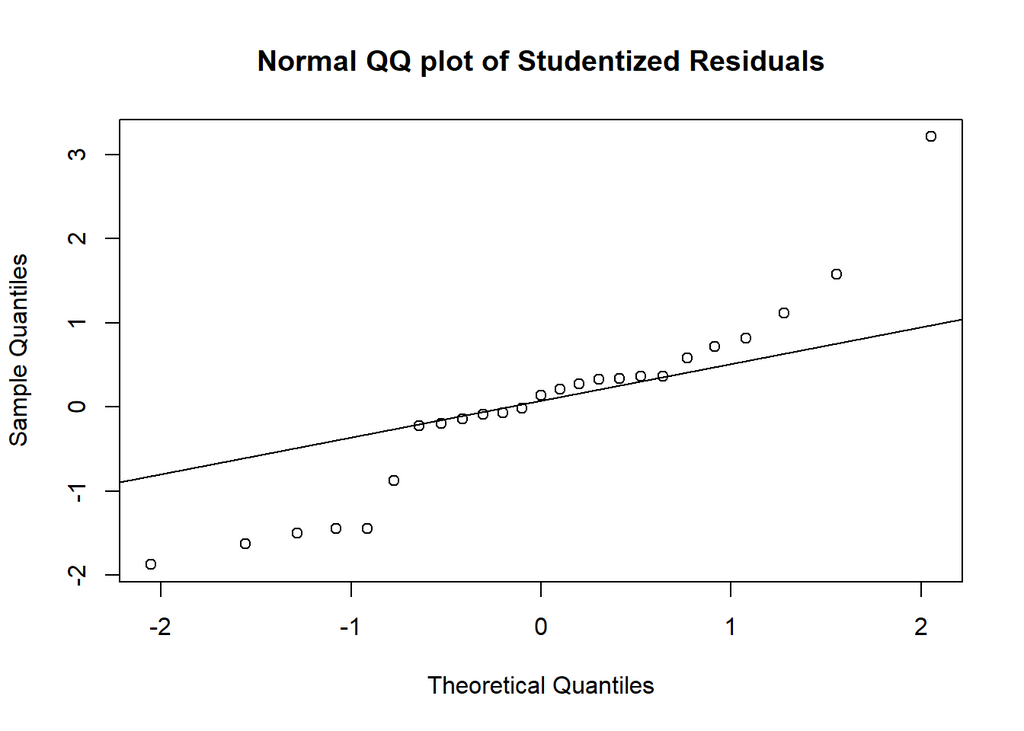

```r
qqnorm(Stud_Res,main="Normal QQ plot of Studentized Residuals")
qqline(Stud_Res)
```

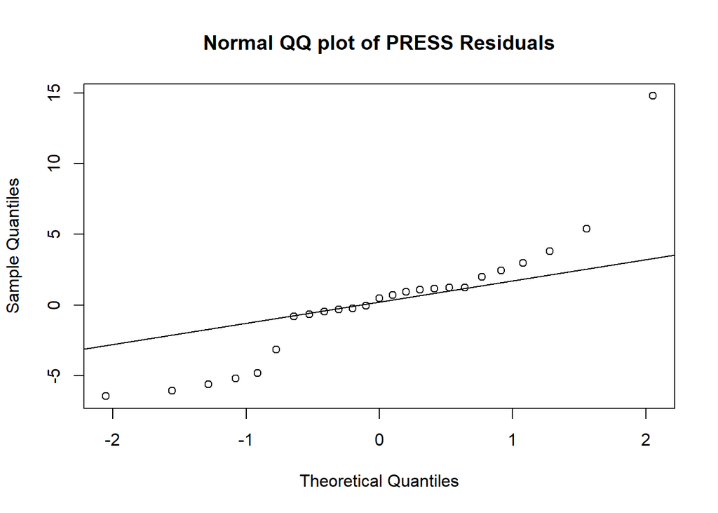

```r
qqnorm(PRESS_Res,main="Normal QQ plot of PRESS Residuals")
qqline(PRESS_Res)
```

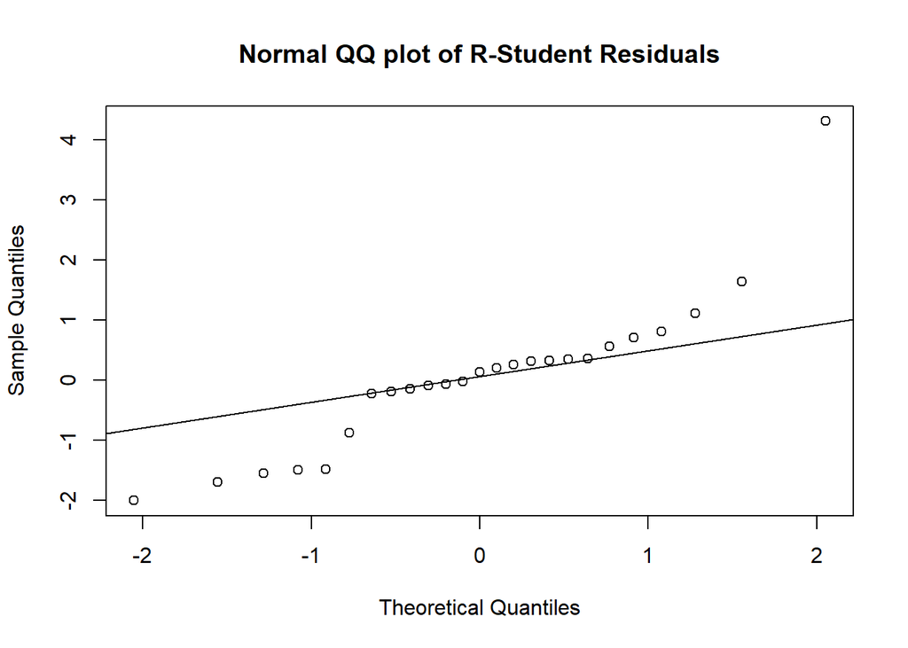

```r
qqnorm(R_Stud,main="Normal QQ plot of R-Student Residuals")
qqline(R_Stud)
```

## Lesson 6 - Example 4.3 (p. 141)

#### Create a plot of residuals against the each of the regressors (Use R-Student residuals)

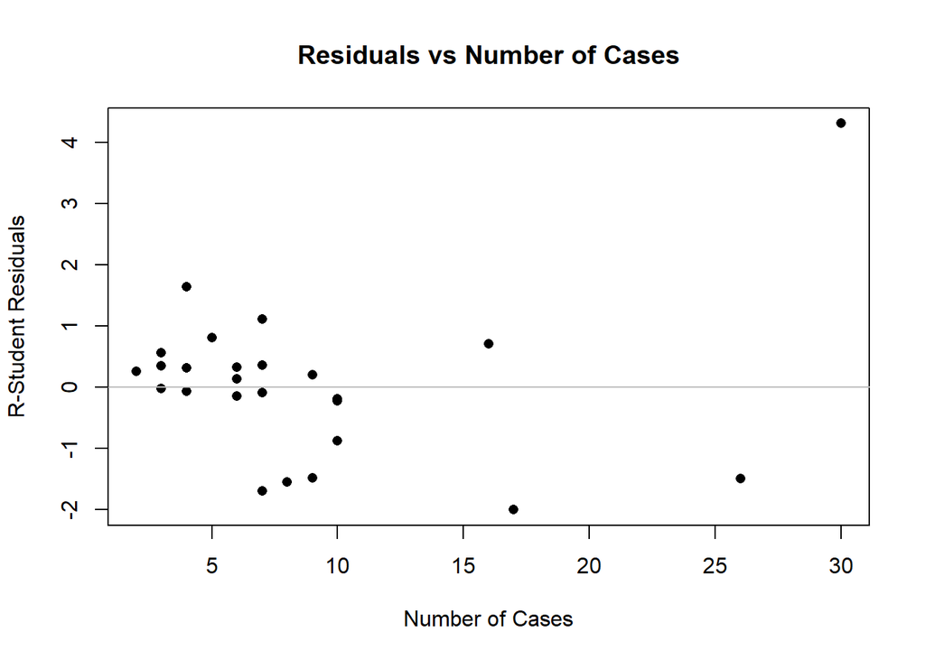

```r
# plot number of cases versus R-student residuals
plot(Num_Cases, R_Stud, ylab = "R-Student Residuals", xlab = "Number of Cases", main = "Residuals vs Number of Cases", pch=16)
abline(h=0, col="gray")
```

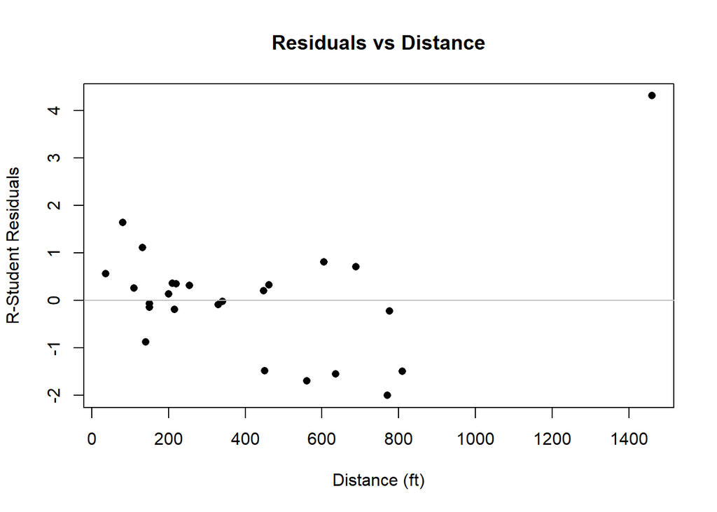

```r
# plot Distance versus R-student residuals
plot(Distance, R_Stud, ylab = "R-Student Residuals", xlab = "Distance (ft)", main = "Residuals vs Distance", pch=16)
abline(h=0, col="gray")
```

## Lesson 6 - Example 4.5 (p. 144)

#### Create partial regression plots for each of the two regressors. Use rstudent() to calculate residuals.

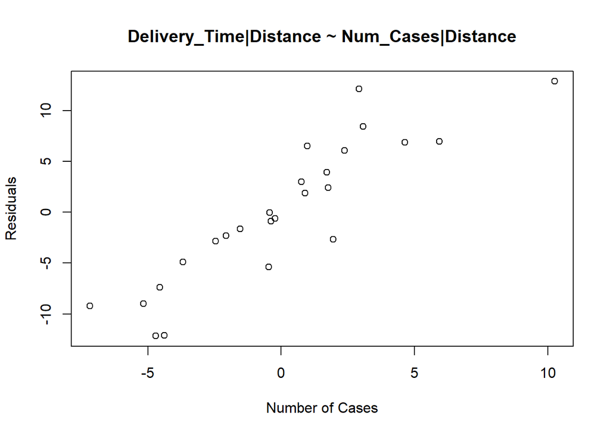

```r
# Delivery_Time, given Distance
model1 <- lm(Delivery_Time ~ Distance )
residuals.1 <- model1$residuals

# Num_Cases, given Distance
model2 <- lm(Num_Cases ~ Distance)
residuals.2 <- model2$residuals

# Delivery_Time, given x1
model3 <- lm(Delivery_Time ~ Num_Cases)
residuals.3 <- model3$residuals

# Distance, given Num_Cases
model4 <- lm(Distance ~ Num_Cases)
residuals.4 <- model4$residuals

plot(residuals.2, residuals.1, main='Delivery_Time|Distance ~ Num_Cases|Distance', xlab = "Number of Cases", ylab = "Residuals")
```

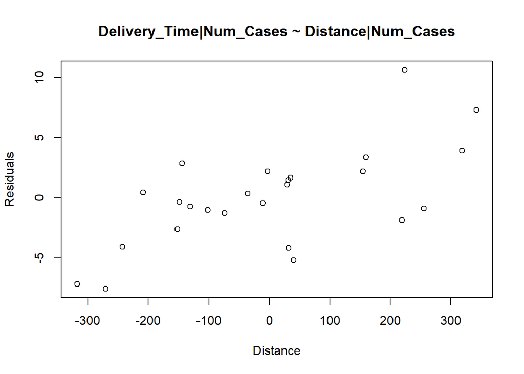

```r
plot(residuals.4, residuals.3, main='Delivery_Time|Num_Cases ~ Distance|Num_Cases', xlab = "Distance", ylab = "Residuals")
```

## Lesson 6 - Example 4.6 (p.151-152)

#### Calculate PRESS Statistic and R-Squared_PRESS (by hand)

```r
# PRESS statistic using eqn 4.17
PRESS_statistic <- sum((Res/(1-diag(H)))^2)

# sum of squares total
SS_T <- t(Delivery_Time)%*%Delivery_Time-(sum(Delivery_Time))^2/length(Delivery_Time)

# R-Squared PRESS using eqn 4.18
R_Squared_PRESS <- 1 - PRESS_statistic/SS_T
```

The PRESS Statistic is $459.0393147$ and the $R^2$ for Prediction Based on PRESS is $R^2_{prediction}$ = $0.9206438$